# Mammal Activity Summary

2024-07-22

# Catch All Markdown for Mammal Community and Activity Summary Figures and Stats

### Behind the Scenes

#### Fix Messed Up Dates in Dataset

#### We should add in some metadata for sorting and analysis purposes

### Ok! Now we can organize and play with the nice clean data (I hope). A summary:

(all numbers have been rounded UP to the nearest integer, except percentages)

[output not shown]

### We can also visualize effort, or how many average nights the cameras were active per month across the year of sampling

In December 2022 only one camera was running (or rather, they were all running but most got washed away or the data was unusable because of storms)

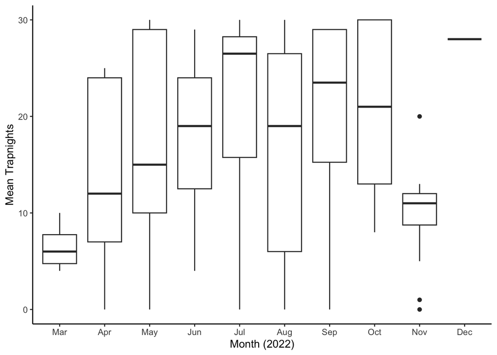

### Is there a seasonal effect on human activity? Probably!

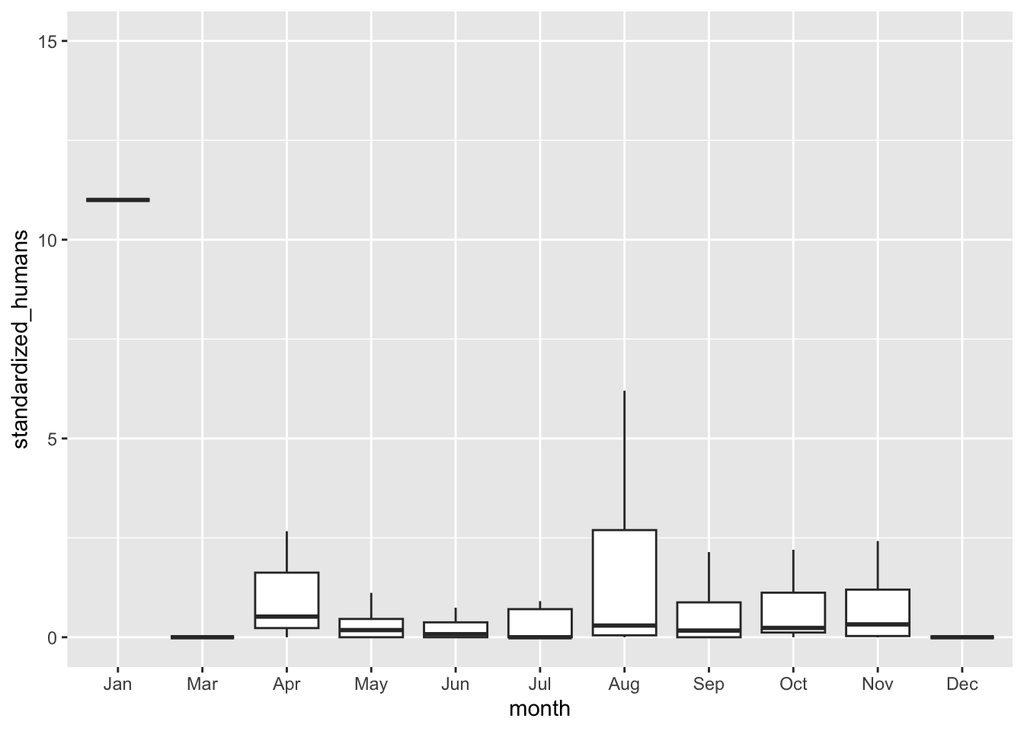

### Finally, let’s get an idea of mammal beach activity/detection, standardized by effort, across the entire year

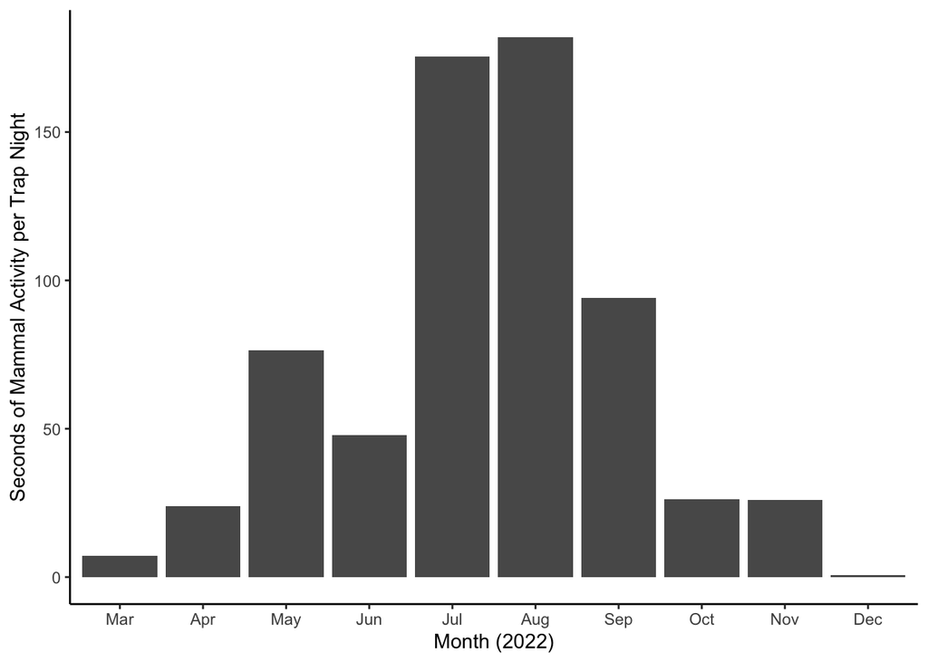

## Let’s visualize rough community composition a couple different ways:

### First, activity by species across the study standardized by effort (trap nights)

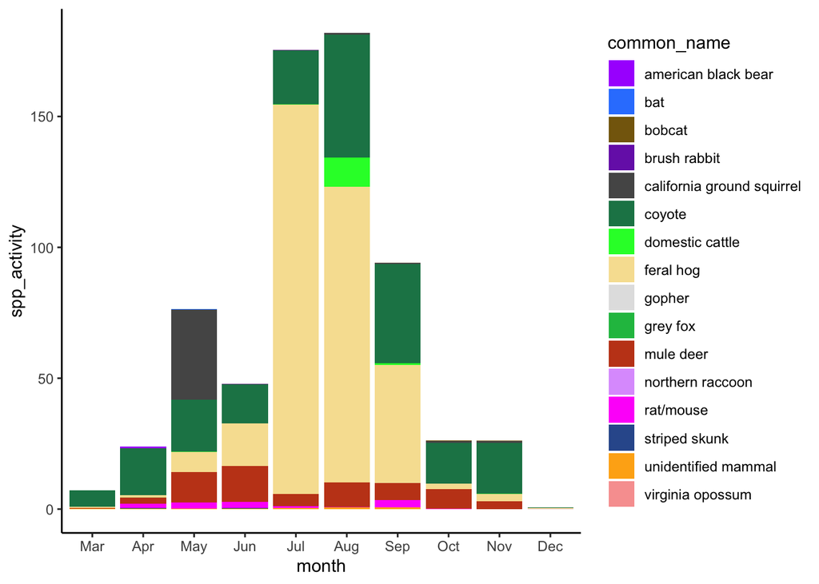

Robin: you might see a coyote every day, but you’ll also see a pig a day and there’s 12 of them

### Then, standardized activity by species but represented as a percentage of the total community

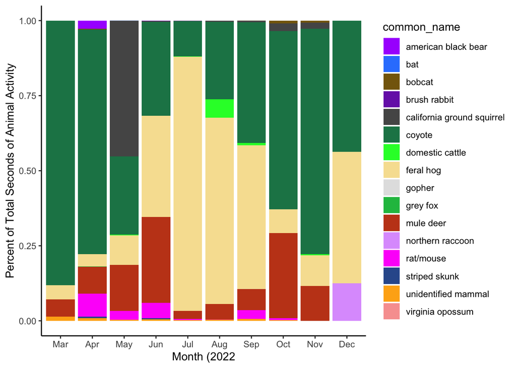

## Now we are ready to use vegan to calculate a bunch of community ecology metrics - the below taken from An Bui’s vegan workshop.

### vegan analysis with site metadata from: https://docs.google.com/spreadsheets/d/1F1pI3ORnCh-Zq6jd1Y11ThUozsBy3iryT9zxW7QCeVY/edit?usp=sharing

### How speciose are my communities?

- one caveat: we lumped all rats & mice into one “species” because they’re super hard to tell apart with cam trap footage

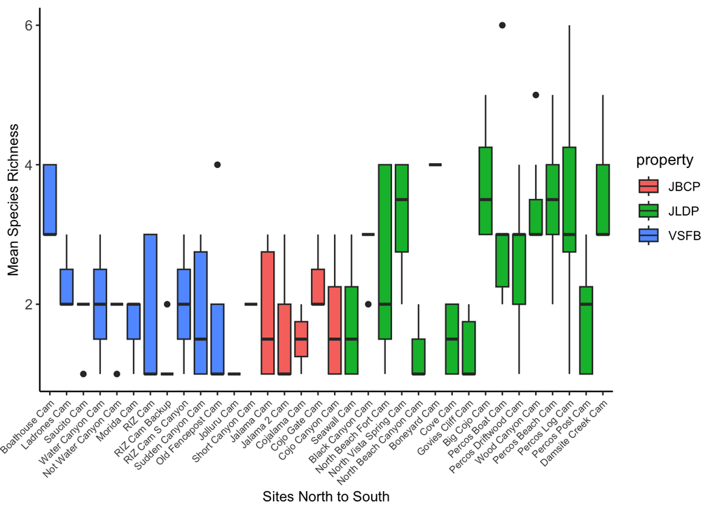

### How diverse are my communities?

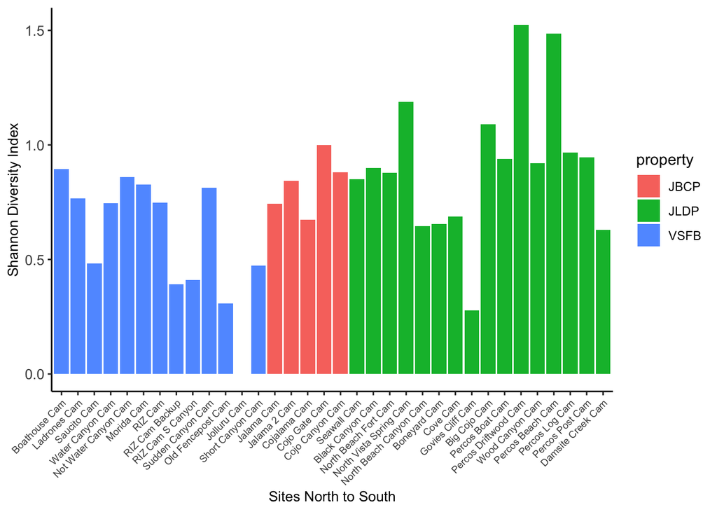

### Is there a correlation between diversity index and human activity?

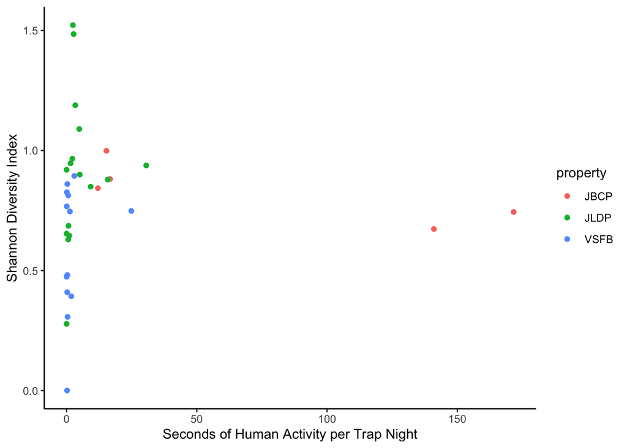

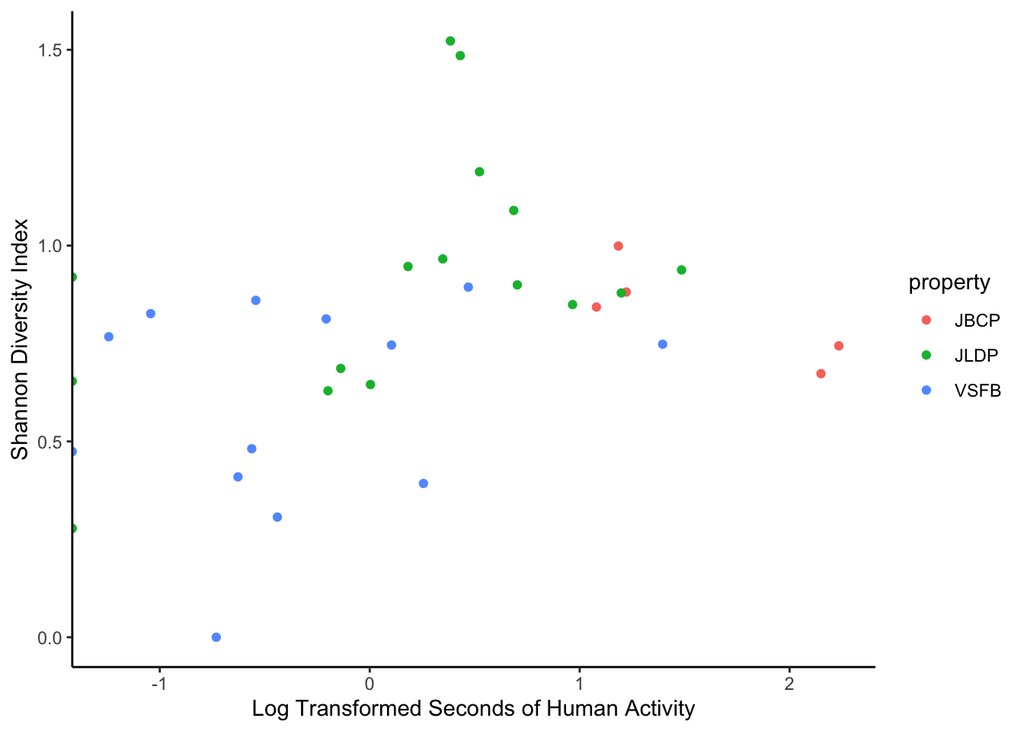

### How different are my communities in species composition?

#### perMANOVA

Permutational analysis of variance: are the centroids of my communities different?

```
## Permutation test for adonis under reduced model
## Terms added sequentially (first to last)
## Permutation: free
## Number of permutations: 999
##
## adonis2(formula = count_matrix_expanded ~ sitename, data = vegan_metadata)
##           Df SumOfSqs      R2     F Pr(>F)
## sitename  33   20.916 0.40607 2.797  0.001 ***
## Residual 135   30.593 0.59393
## Total    168   51.509 1.00000
## ---
## Signif. codes:  0 '***' 0.001 '**' 0.01 '*' 0.05 '.' 0.1 ' ' 1
```

Looks like they are.